# Baseball data

DSCI 632: Statistics for Data Science

Peter Ralph

# Baseball

## Baseball

We have a dataset of batting averages of baseball players, having

1. name
2. position
3. number of at bats
4. number of hits
5. height
6. weight
7. handedness

```r
batting <- read.csv("data/BattingAveragePlus.csv", header=TRUE, stringsAsFactors=TRUE)
head(batting)
```

```
##             Player     PriPos Hits AtBats PlayerNumber PriPosNumber  playerID weight height bats birthYear      debut  finalGame
## 1 Aaron Cunningham Left Field   17     97          198            7 cunniaa01    215     71    R      1986 2008-08-31 2012-07-24
## 2     Aaron Harang    Pitcher    4     56          360            1 haranaa01    260     79    R      1978 2002-05-25 2015-10-03
## 3       Aaron Hill   2nd Base  184    609          394            4  hillaa01    200     71    R      1982 2005-05-20 2016-10-01
## 4     Aaron Laffey    Pitcher    0      1          482            1 laffeaa01    190     71    L      1985 2007-08-04 2015-07-31
## 5       Aaron Loup    Pitcher    0      1          522            1  loupaa01    210     71    L      1987 2012-07-14 2016-09-30
## 6        Adam Dunn   1st Base  110    539          242            3  dunnad01    285     78    L      1979 2001-07-20 2014-09-28
```

The *overall* batting average of the 886 players is 0.254768.

Here is the average by position.

```r
batting |>
    summarise(num=n(), BatAvg=sum(Hits)/sum(AtBats), .by=PriPos) |>
    select(PriPos, num, BatAvg)
```

```
##         PriPos num    BatAvg
## 1   Left Field  96 0.2581975
## 2      Pitcher 305 0.1298812
## 3     2nd Base  69 0.2555241
## 4     1st Base  77 0.2599845
## 5 Center Field  61 0.2647517
## 6     3rd Base  73 0.2651765
## 7      Catcher  95 0.2469504
## 8    Shortstop  57 0.2550538
## 9  Right Field  53 0.2630511
```

## Questions?

1. What’s the overall batting average?
2. Do some positions tend to be better batters?
3. How much variation in batting average is there between players of the same position?
4. Do height or weight predict batting average?

**Exercise:**

*Come up with some quick-and-dirty statistics to answer these questions.*

## IN CLASS: exploration

*Observations:*

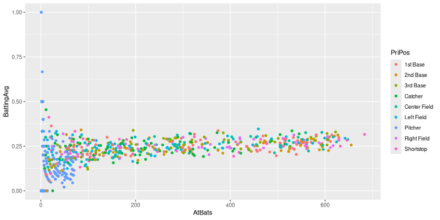

```r
batting |> mutate(BattingAvg = Hits/AtBats) |>
    ggplot(aes(x=AtBats, y=BattingAvg, color=PriPos)) + geom_point()
```

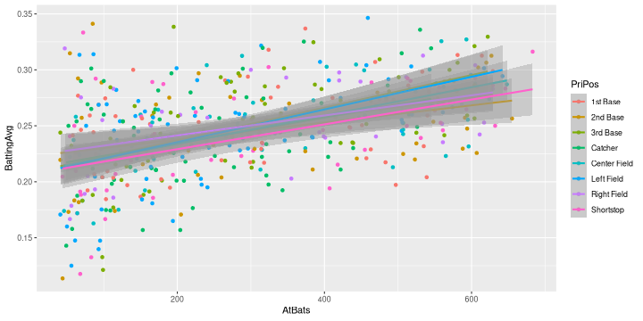

```r
batting |> mutate(BattingAvg = Hits/AtBats) |>
    filter(PriPos != "Pitcher" & AtBats > 40) |>
    ggplot(aes(x=AtBats, y=BattingAvg, color=PriPos)) + geom_point() +
    geom_smooth(method="lm")
```

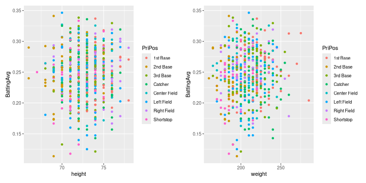

```r
p1 <- batting |> mutate(BattingAvg = Hits/AtBats) |>
    filter(PriPos != "Pitcher" & AtBats > 40) |>
    ggplot(aes(x=height, y=BattingAvg, color=PriPos)) + geom_point()
p2 <- batting |> mutate(BattingAvg = Hits/AtBats) |>
    filter(PriPos != "Pitcher" & AtBats > 40) |>
    ggplot(aes(x=weight, y=BattingAvg, color=PriPos)) + geom_point()
p1 | p2
```

# Predicting probabilities

*Motivation:*

```r
lm( Hits/AtBats ~ PriPos + weight + height, data=batting )
```

which is
$$\begin{aligned}
\frac{\text{Hits}_i}{\text{AtBats}_i} &\sim \Normal(\mu_i,
\sigma) \\
\mu_i &= \beta_0 + \beta_{\text{PriPos}_i} + \beta_w w_i +
\beta_h h_i
\end{aligned}$$

*But:* that’s not right - `Hits/AtBats` is between 0 and 1!

And, 2/5 is very different than 2000/5000!

## A better Binomial model

$$\begin{aligned}
\text{Hits}_i &\sim \Binom(\text{AtBats}_i, \mu_i) \\
\mu_i &= \beta_0 + \beta_{\text{PriPos}_i} + \beta_w w_i +
\beta_h h_i
\end{aligned}$$

*But:* what’s to keep $\mu_i$ between 0 and 1?

# The logistic function

## The logistic function

$$\begin{aligned}
\logistic(x) = \frac{1}{1 + e^{-x}} .
\end{aligned}$$

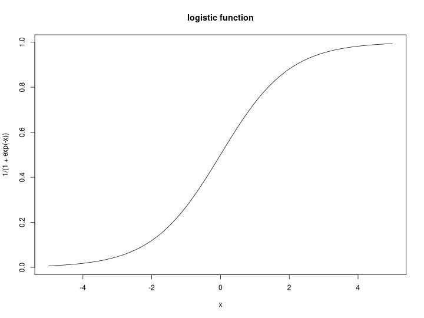

## … is the inverse of the logit function

$$\begin{aligned}
\logit(x) = \log\left(\frac{x}{1-x}\right) .
\end{aligned}$$

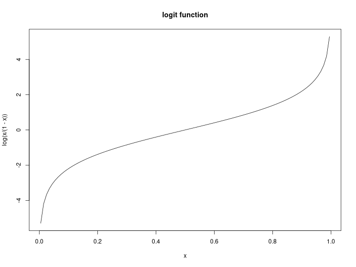

# Let’s build a model

## Binomial response with logistic predictor

$$\begin{aligned}
Z_i &\sim \Binom(N_i, \theta_i) \\
\theta_i &= \logistic(\mu_i)
\end{aligned}$$

For the $i$th player:

- $N_i$: number of *at-bats*
- $Z_i$: number of *hits*
- $\theta_i$: “true” batting average

## Everyone is the same

$$\begin{aligned}
Z_i &\sim \Binom(N_i, \theta_i) \\
\theta_i &= \logistic(\mu_i) \\
\mu_i &= \beta_0
\end{aligned}$$

For the $i$th player:

- $N_i$: number of *at-bats*
- $Z_i$: number of *hits*
- $\theta_i$: “true” batting average

and

- $\beta_0$: overall mean logit batting avg

## All pitchers are the same

$$\begin{aligned}
Z_i &\sim \Binom(N_i, \theta_i) \\
\theta_i &= \logistic(\mu_i) \\
\mu_i &= \beta_{p_i}
\end{aligned}$$

For the $i$th player:

- $N_i$: number of *at-bats*
- $Z_i$: number of *hits*
- $p_i$: *position*

and

- $\beta_p$: mean logit batting avg of position $p$

# First model, with brms

## First, we need priors!

$$\begin{aligned}
Z_i &\sim \Binom(N_i, \theta_i) \\
\theta_i &= \logistic(\mu_i) \\
\mu_i &= \beta_{p_i}
\end{aligned}$$
and
$$\begin{aligned}
\beta_p &\sim \Normal(0, 5)
\end{aligned}$$

For the $i$th player:

- $N_i$: number of *at-bats*
- $Z_i$: number of *hits*
- $p_i$: *position*

and

- $\beta_p$: mean logit batting avg of position $p$

## Fit the model

We’ll see more about [brms](https://paul-buerkner.github.io/brms/reference/brm.html) soon!

```r
fm <- brm(
      Hits  | trials(AtBats) ~ 0 + PriPos,
      data=batting,
      family='binomial',
      prior = c(prior(normal(0, 5), class = b)),
      iter = 2000, chains = 3
)
```

## Check convergence

```r
print(fm)
```

```
##  Family: binomial
##   Links: mu = logit
## Formula: Hits | trials(AtBats) ~ 0 + PriPos
##    Data: batting (Number of observations: 886)
##   Draws: 3 chains, each with iter = 2000; warmup = 1000; thin = 1;
##          total post-warmup draws = 3000
##
## Regression Coefficients:
##                   Estimate Est.Error l-95% CI u-95% CI Rhat Bulk_ESS Tail_ESS
## PriPos1stBase        -1.05      0.02    -1.08    -1.02 1.00     5119     1824
## PriPos2ndBase        -1.07      0.02    -1.10    -1.04 1.00     5204     2238
## PriPos3rdBase        -1.02      0.02    -1.05    -0.99 1.00     6188     2145
## PriPosCatcher        -1.12      0.02    -1.15    -1.08 1.00     6505     2192
## PriPosCenterField    -1.02      0.02    -1.05    -0.99 1.00     4680     2237
## PriPosLeftField      -1.05      0.02    -1.09    -1.02 1.00     5518     1954
## PriPosPitcher        -1.90      0.04    -1.99    -1.82 1.00     5624     2095
## PriPosRightField     -1.03      0.02    -1.07    -1.00 1.00     5961     2344
## PriPosShortstop      -1.07      0.02    -1.11    -1.04 1.00     5592     2175
##
## Draws were sampled using sampling(NUTS). For each parameter, Bulk_ESS
## and Tail_ESS are effective sample size measures, and Rhat is the potential
## scale reduction factor on split chains (at convergence, Rhat = 1).
```

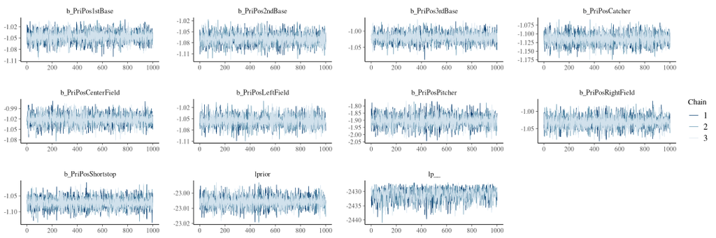

```r
mcmc_trace(fm)
```

## Results: on a logit scale

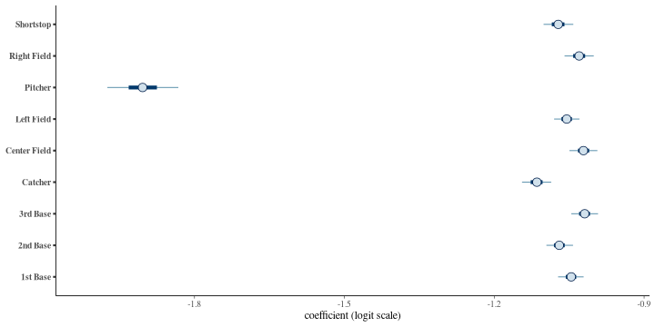

```r
mcmc_intervals(fm, regex_pars="b_PriPos.*") +
    scale_y_discrete(labels=levels(batting$PriPos)) +
    xlab("coefficient (logit scale)")
```

## Results: with `predict( )`

```r
nhits <- 10000
post_df <- data.frame(
            PriPos=levels(batting$PriPos),
            AtBats=nhits)
fm_post <- predict(fm, newdata=post_df)
post_df <- cbind(post_df, fm_post)
```

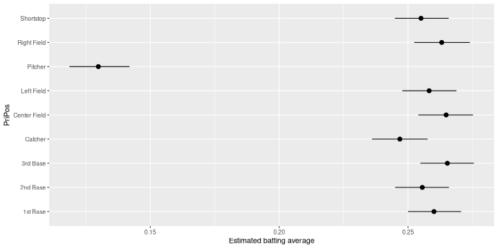

```r
post_df |>  ggplot(aes(x=Estimate/nhits, xmin=Q2.5/nhits, xmax=Q97.5/nhits, y=PriPos)) +
    geom_pointrange() + labs(x="Estimated batting average")
```

## Are right fielders better than catchers?

Let’s get the posterior distribution of the difference between the two batting averages.

```r
fm_samps <- posterior_epred(fm, newdata=post_df)
colnames(fm_samps) <- post_df$PriPos
fm_samps <- data.frame(fm_samps)
```

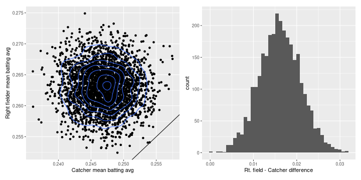

## Goodness-of-fit

*Is* this a good model for the data? (Why do you suspect it might not be?)

We can use `predict` to ask *under the model* what we expect the range of data values (`Hits`) to be.

```r
fm_pp <- predict(fm)
head(fm_pp)
```

```
##         Estimate  Est.Error Q2.5 Q97.5
## [1,]  25.0523333  4.3287998   17    34
## [2,]   7.2833333  2.5351919    3    13
## [3,] 155.5256667 10.9938602  133   177
## [4,]   0.1306667  0.3370916    0     1
## [5,]   0.1346667  0.3414241    0     1
## [6,] 140.2316667 10.3042413  120   161
```

## A posterior predictive check:

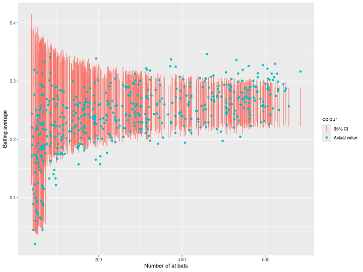

# Exercise

Simulate from the model:

1. Make up 20 players’ names, positions, and at-bats,
2. simulate their true batting averages as on the right,
3. and draw their Hits using `rbinom( )`.

Then, fit the model! (time remaining)

$$\begin{aligned}
Z_i &\sim \Binom(N_i, \theta_i) \\
\theta_i &= \frac{1}{1 + \exp(-\mu_i)} \\
\mu_i &= \beta_{p_i} + \epsilon_i \\
\epsilon_i &\sim \Normal(0, 0.05) .
\end{aligned}$$

with:

- $\beta_\text{pitcher} = -1.73$
- and all other $\beta_p = -1.15$

## IN CLASS

```r
n <- 15 # number of players
positions <- c("pitcher", "catcher", "right field")
sim_batting <- data.frame(
    name = c("jared", "sam", "bryce", "becky", "frankie", "ball",
             "ana", "jack", "buster", "sam", "bob", "martha", "mike",
             "jake", "peter"),
   position = sample(positions, n, replace=TRUE),
   AtBats = rpois(n, 200)
)

true_betas <- c(pitcher= -1.73,
                catcher=-1.15,
                "right field" = -1.15)
stopifnot(all(names(true_betas) == positions))

sim_batting <- sim_batting |> mutate(
    mu = true_betas[position] + rnorm(n, mean=0, sd=0.05),
    theta = 1/(1 + exp(-mu)),
    hits = rbinom(n, size=AtBats, prob=theta)
)
```

```r
library(lme4)
sim_batting$id <- 1:nrow(sim_batting)
brm(hits | trials(AtBats) ~ 0 + position + (1|id),
     family="binomial",
     data=sim_batting
) |> summary()
```

# Back to the model

## Everyone is different, but pitchers are similar

$$\begin{aligned}
Z_i &\sim \Binom(N_i, \theta_i) \\
\theta_i &= \logistic(\mu_i) \\
\mu_i &= \beta_{p_i} + \epsilon_i \\
\epsilon_i &\sim \Normal(0, \sigma)
\end{aligned}$$

For the $i$th player:

- $N_i$: number of *at-bats*
- $Z_i$: number of *hits*
- $p_i$: *position*
- $\epsilon_i$: difference to typical for position

and

- $\beta_p$: batting avg for position $p$
- $\sigma$: size of differences between players

## Add in height and weight

$$\begin{aligned}
Z_i &\sim \Binom(N_i, \theta_i) \\
\theta_i &= \logistic(\mu_i) \\
\mu_i &= \beta_{p_i} + \beta_h h_i + \beta_w w_i + \epsilon_i \\
\epsilon_i &\sim \Normal(0, \sigma)
\end{aligned}$$

For the $i$th player:

- $N_i$: number of *at-bats*
- $Z_i$: number of *hits*
- $p_i$: *position*
- $\epsilon_i$: difference to typical for position
- $h_i$, $w_i$: height and weight

and

- $\beta_p$: batting avg for position $p$
- $\sigma$: size of differences between players
- $\beta_h$, $\beta_w$: coefficients on height and weight

## Fit the model

Scaling variables can improve convergence:

```r
library(brms)
batting$scaled_height <- (batting$height - mean(batting$height))/sd(batting$height)
batting$scaled_weight <- (batting$weight - mean(batting$weight))/sd(batting$weight)
logistic_fit <- brm(
      Hits  | trials(AtBats) ~ 0 + scaled_weight + scaled_height + PriPos + (1 | PriPos:Player),
      data = batting,
      family = "binomial",
      prior = c(prior(normal(0, 5), class = b),
                prior(normal(0, 5), class = sd)),
      iter = 2000, chains = 3
)
```

## Check convergence

```r
print(logistic_fit)
```

```
##  Family: binomial
##   Links: mu = logit
## Formula: Hits | trials(AtBats) ~ 0 + scaled_weight + scaled_height + PriPos + (1 | PriPos:Player)
##    Data: batting (Number of observations: 886)
##   Draws: 3 chains, each with iter = 2000; warmup = 1000; thin = 1;
##          total post-warmup draws = 3000
##
## Multilevel Hyperparameters:
## ~PriPos:Player (Number of levels: 886)
##               Estimate Est.Error l-95% CI u-95% CI Rhat Bulk_ESS Tail_ESS
## sd(Intercept)     0.14      0.01     0.12     0.16 1.01     1216     1894
##
## Regression Coefficients:
##                   Estimate Est.Error l-95% CI u-95% CI Rhat Bulk_ESS Tail_ESS
## scaled_weight         0.02      0.01    -0.01     0.04 1.00     1108     1566
## scaled_height        -0.01      0.01    -0.03     0.02 1.00     1277     1607
## PriPos1stBase        -1.08      0.03    -1.13    -1.03 1.00     1287     1866
## PriPos2ndBase        -1.09      0.03    -1.15    -1.04 1.00     1427     1772
## PriPos3rdBase        -1.06      0.02    -1.10    -1.01 1.00     1546     2053
## PriPosCatcher        -1.16      0.03    -1.21    -1.11 1.00     1697     2134
## PriPosCenterField    -1.05      0.03    -1.10    -0.99 1.00     1305     1571
## PriPosLeftField      -1.10      0.02    -1.14    -1.05 1.00     1426     1976
## PriPosPitcher        -1.91      0.05    -2.00    -1.83 1.00     4113     2420
## PriPosRightField     -1.05      0.03    -1.11    -1.00 1.00     1507     2176
## PriPosShortstop      -1.10      0.03    -1.16    -1.04 1.00     1350     1749
##
## Draws were sampled using sampling(NUTS). For each parameter, Bulk_ESS
## and Tail_ESS are effective sample size measures, and Rhat is the potential
## scale reduction factor on split chains (at convergence, Rhat = 1).
```

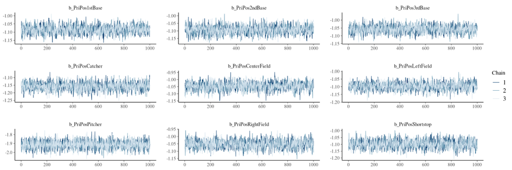

```r
mcmc_trace(logistic_fit, regex_pars="b_PriPos.*")
```

## Look at results

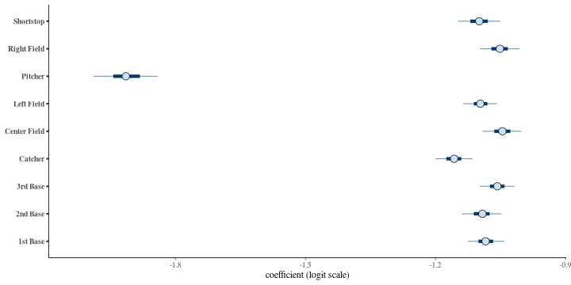

```r
samps <- as_draws_array(logistic_fit)
mcmc_intervals(samps, regex_pars=c("b_PriPos.*")) +
    scale_y_discrete(labels=levels(batting$PriPos)) +
    xlab("coefficient (logit scale)")
```

## In the natural scale

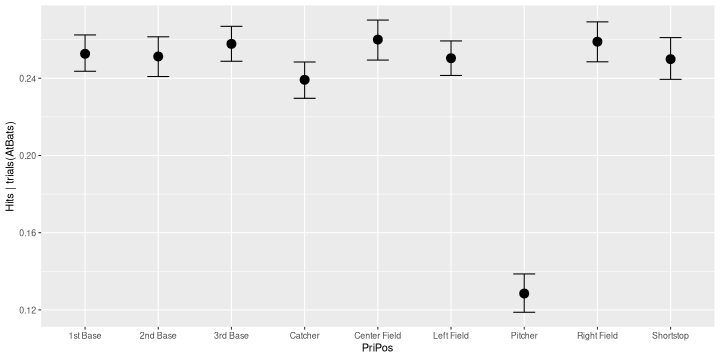

```r
conditional_effects(logistic_fit, effects="PriPos", trials=1)
```

## Let’s look at some players?

`posterior_epred()` gives posterior samples of expected responses:

```r
players <- c("John Buck", "Pedro Alvarez", "Prince Fielder")
(player_data <- subset(batting, Player %in% players))
```

```
##             Player   PriPos Hits AtBats PlayerNumber PriPosNumber  playerID weight height bats birthYear      debut  finalGame scaled_height scaled_weight
## 463      John Buck  Catcher   66    343          100            2  buckjo01    245     75    R      1980 2004-06-25 2014-09-28     0.6893737      1.639713
## 695  Pedro Alvarez 3rd Base  128    525           12            5 alvarpe01    250     75    L      1987 2010-06-16 2016-10-01     0.6893737      1.884274
## 704 Prince Fielder 1st Base  182    581          267            3 fieldpr01    275     71    L      1984 2005-06-13 2016-07-18    -1.0408956      3.107075
```

```r
player_preds <- posterior_epred(logistic_fit, newdata=player_data)
colnames(player_preds) <- players
player_preds <- (player_preds / player_data$AtBats[col(player_preds)]) |> data.frame()
head(player_preds)
```

```
##   John.Buck Pedro.Alvarez Prince.Fielder
## 1 0.2277339     0.2418322      0.2847151
## 2 0.2105962     0.2687755      0.2999993
## 3 0.1982912     0.2738370      0.3079046
## 4 0.2257161     0.2373947      0.2961034
## 5 0.1985864     0.2627992      0.3272385
## 6 0.2090003     0.2464034      0.2872320
```

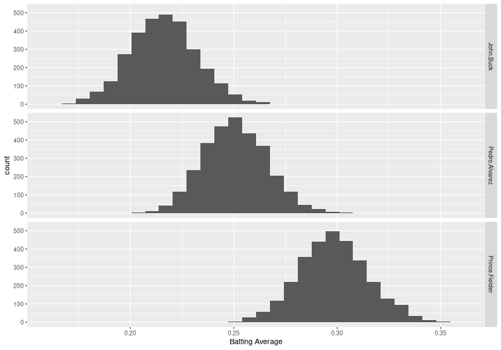

```r
player_preds |> pivot_longer(cols=everything(), names_to="Player", values_to="BattingAvg") |>
    ggplot(aes(x=BattingAvg)) + geom_histogram(bins=30) +
    facet_grid(Player ~ .) + labs(x="Batting Average")
```

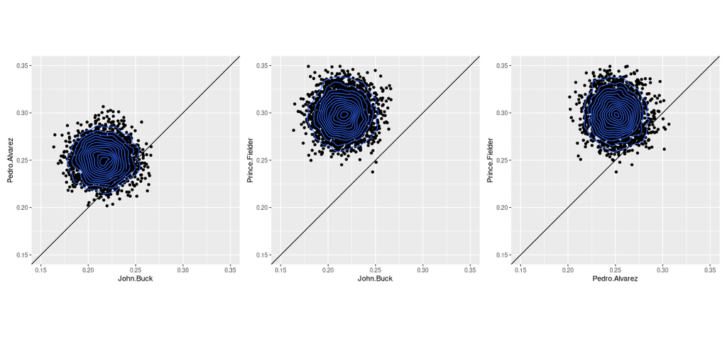

```r
make_plot <- function (i, j) {
    pi <- make.names(players[i])
    pj <- make.names(players[j])
    player_preds |>
    ggplot(aes(x=!!sym(pi), y=!!sym(pj))) + geom_point() +
        geom_density_2d() +  geom_abline(slope=1, intercept=0) +
        lims(x=c(0.15, 0.35), y=c(0.15, 0.35)) +
        theme(aspect.ratio=1)
}
make_plot(1, 2) | make_plot(1, 3) | make_plot(2, 3)
```

Do we have good evidence the players are different?

```r
hypothesis(player_preds, c("John.Buck < Pedro.Alvarez", "John.Buck < Prince.Fielder", "Pedro.Alvarez < Prince.Fielder"))
```

```
## Hypothesis Tests for class :
##                 Hypothesis Estimate Est.Error CI.Lower CI.Upper Evid.Ratio Post.Prob Star
## 1 (John.Buck)-(Pedr... < 0    -0.03      0.02    -0.07     0.00      15.04      0.94
## 2 (John.Buck)-(Prin... < 0    -0.08      0.02    -0.12    -0.05    1499.00      1.00    *
## 3 (Pedro.Alvarez)-(... < 0    -0.05      0.02    -0.09    -0.01      48.18      0.98    *
## ---
## 'CI': 90%-CI for one-sided and 95%-CI for two-sided hypotheses.
## '*': For one-sided hypotheses, the posterior probability exceeds 95%;
## for two-sided hypotheses, the value tested against lies outside the 95%-CI.
## Posterior probabilities of point hypotheses assume equal prior probabilities.
```

## Exercise:

What are some questions would you like to answer using this model?